# Star Wars Survey

# Next Steps

**Try to segment the data based on columns like Education, Location (Census Region), and Which character shot first?, which aren't binary. Are they any interesting patterns?**

```python
# check values in the Education column
star_wars["Education"].value_counts()
```

```
Some college or Associate degree    328
Bachelor degree                     321
Graduate degree                     275
High school degree                  105
Less than high school degree          7
Name: Education, dtype: int64
```

```python
# check values in the Location column
star_wars["Location (Census Region)"].value_counts()
```

```
East North Central    181
Pacific               175
South Atlantic        170
Middle Atlantic       122
West South Central    110
West North Central     93
Mountain               79
New England            75
East South Central     38
Name: Location (Census Region), dtype: int64
```

```python
# check values in the "Which character shot first?" column
star_wars["Which character shot first?"].value_counts()
```

```
Han                                 325
I don't understand this question    306
Greedo                              197
Name: Which character shot first?, dtype: int64
```

```python
# check values in the "Which character shot first?" column among fans
fans["Which character shot first?"].value_counts()
```

```
Han                                 268
Greedo                              151
I don't understand this question    126
Name: Which character shot first?, dtype: int64
```

```python
# check fans who are true Star Wars fans
fans[(fans["seen_4"]==True) & (fans["seen_5"]==True) & (fans["seen_4"]==True) & (fans["Which character shot first?"] == "Han")]
```

|  | RespondentID | Have you seen any of the 6 films in the Star Wars franchise? | Do you consider yourself to be a fan of the Star Wars film franchise? | seen_1 | seen_2 | seen_3 | seen_4 | seen_5 | seen_6 | ranking_1 | ... | Unnamed: 28 | Which character shot first? | Are you familiar with the Expanded Universe? | Do you consider yourself to be a fan of the Expanded Universe?æ | Do you consider yourself to be a fan of the Star Trek franchise? | Gender | Age | Household Income | Education | Location (Census Region) |
| --- | --- | --- | --- | --- | --- | --- | --- | --- | --- | --- | --- | --- | --- | --- | --- | --- | --- | --- | --- | --- | --- |
| 6 | 3.292719e+09 | True | True | True | True | True | True | True | True | 1.0 | ... | Very favorably | Han | Yes | No | Yes | Male | 18-29 | $25,000 - $49,999 | Bachelor degree | Middle Atlantic |
| 7 | 3.292685e+09 | True | True | True | True | True | True | True | True | 6.0 | ... | Very favorably | Han | Yes | No | No | Male | 18-29 | NaN | High school degree | East North Central |
| 8 | 3.292664e+09 | True | True | True | True | True | True | True | True | 4.0 | ... | Very favorably | Han | No | NaN | Yes | Male | 18-29 | NaN | High school degree | South Atlantic |
| 9 | 3.292654e+09 | True | True | True | True | True | True | True | True | 5.0 | ... | Somewhat favorably | Han | No | NaN | No | Male | 18-29 | $0 - $24,999 | Some college or Associate degree | South Atlantic |
| 15 | 3.292587e+09 | True | True | True | True | True | True | True | True | 4.0 | ... | Very favorably | Han | No | NaN | No | Male | 18-29 | NaN | High school degree | East North Central |
| 16 | 3.292583e+09 | True | True | True | True | True | True | True | True | 4.0 | ... | Somewhat favorably | Han | Yes | Yes | Yes | Male | 18-29 | $0 - $24,999 | Some college or Associate degree | West South Central |
| 19 | 3.292565e+09 | True | True | True | True | True | True | True | True | 6.0 | ... | Very favorably | Han | No | NaN | No | Male | 18-29 | NaN | High school degree | South Atlantic |
| 21 | 3.292522e+09 | True | True | True | True | True | True | True | True | 6.0 | ... | Very favorably | Han | No | NaN | No | Male | 18-29 | NaN | Some college or Associate degree | Pacific |
| 24 | 3.292483e+09 | True | True | True | True | True | True | True | True | 6.0 | ... | Very favorably | Han | No | NaN | No | Male | 18-29 | $0 - $24,999 | Bachelor degree | Pacific |
| 25 | 3.292465e+09 | True | True | True | True | True | True | True | True | 1.0 | ... | Very favorably | Han | No | NaN | No | Male | 18-29 | NaN | NaN | East North Central |
| 29 | 3.292380e+09 | True | True | True | True | True | True | True | True | 6.0 | ... | Very favorably | Han | Yes | No | No | Male | 18-29 | NaN | Some college or Associate degree | Middle Atlantic |
| 30 | 3.292377e+09 | True | True | True | True | True | True | True | True | 4.0 | ... | Very favorably | Han | Yes | Yes | Yes | Male | 18-29 | $150,000+ | Some college or Associate degree | East North Central |
| 32 | 3.292339e+09 | True | True | True | True | True | True | True | True | 6.0 | ... | Very favorably | Han | Yes | Yes | Yes | Male | 30-44 | $50,000 - $99,999 | Some college or Associate degree | West North Central |
| 36 | 3.292291e+09 | True | True | True | True | True | True | True | True | 6.0 | ... | Very favorably | Han | No | NaN | No | Male | 30-44 | $150,000+ | Graduate degree | East North Central |
| 38 | 3.292280e+09 | True | True | True | True | True | True | True | True | 2.0 | ... | Somewhat favorably | Han | No | NaN | No | Male | 18-29 | NaN | Some college or Associate degree | Pacific |
| 39 | 3.292264e+09 | True | True | True | True | True | True | True | True | 6.0 | ... | Somewhat favorably | Han | Yes | No | Yes | Male | 30-44 | $50,000 - $99,999 | Bachelor degree | Middle Atlantic |
| 41 | 3.292249e+09 | True | True | True | True | True | True | True | True | 5.0 | ... | Very favorably | Han | No | NaN | Yes | Male | 30-44 | $100,000 - $149,999 | Graduate degree | Middle Atlantic |
| 42 | 3.292223e+09 | True | True | True | True | True | True | True | True | 6.0 | ... | Very favorably | Han | Yes | Yes | No | Male | 30-44 | $100,000 - $149,999 | Graduate degree | Pacific |
| 44 | 3.292218e+09 | True | True | True | True | True | True | True | True | 6.0 | ... | Very favorably | Han | Yes | Yes | Yes | Male | 18-29 | $150,000+ | Bachelor degree | Pacific |
| 45 | 3.292214e+09 | True | True | True | True | True | True | True | True | 5.0 | ... | Somewhat favorably | Han | Yes | No | No | Male | 18-29 | $25,000 - $49,999 | High school degree | New England |
| 46 | 3.292211e+09 | True | True | True | True | True | True | True | True | 6.0 | ... | Very favorably | Han | No | NaN | No | Male | 18-29 | NaN | Some college or Associate degree | West North Central |
| 48 | 3.292190e+09 | True | True | True | True | True | True | True | True | 5.0 | ... | Very favorably | Han | Yes | Yes | Yes | Male | 30-44 | $50,000 - $99,999 | Some college or Associate degree | West North Central |
| 52 | 3.292177e+09 | True | True | True | True | True | True | True | True | 6.0 | ... | Very favorably | Han | Yes | No | No | Male | 18-29 | NaN | High school degree | South Atlantic |
| 54 | 3.292167e+09 | True | True | True | True | True | True | True | True | 5.0 | ... | Somewhat favorably | Han | Yes | No | No | Male | 18-29 | $25,000 - $49,999 | High school degree | New England |
| 57 | 3.292157e+09 | True | True | True | True | True | True | True | True | 4.0 | ... | Very favorably | Han | No | NaN | No | Male | 18-29 | $150,000+ | Bachelor degree | West South Central |
| 58 | 3.292149e+09 | True | True | True | True | True | True | True | True | 6.0 | ... | Somewhat favorably | Han | No | NaN | Yes | Male | 18-29 | $50,000 - $99,999 | Graduate degree | West North Central |
| 59 | 3.292145e+09 | True | True | True | True | True | True | True | True | 6.0 | ... | Very favorably | Han | Yes | Yes | No | Male | 18-29 | $0 - $24,999 | High school degree | New England |
| 63 | 3.292120e+09 | True | True | True | True | True | True | True | True | 4.0 | ... | Very favorably | Han | Yes | Yes | No | Male | 18-29 | $100,000 - $149,999 | Some college or Associate degree | New England |
| 66 | 3.292041e+09 | True | True | True | True | True | True | True | True | 6.0 | ... | Very favorably | Han | Yes | Yes | Yes | Male | 18-29 | $150,000+ | Some college or Associate degree | East South Central |
| 69 | 3.292009e+09 | True | True | True | True | True | True | True | True | 5.0 | ... | Somewhat favorably | Han | Yes | Yes | Yes | Male | 18-29 | $25,000 - $49,999 | Some college or Associate degree | East South Central |
| ... | ... | ... | ... | ... | ... | ... | ... | ... | ... | ... | ... | ... | ... | ... | ... | ... | ... | ... | ... | ... | ... |
| 1017 | 3.288653e+09 | True | True | True | True | True | True | True | True | 3.0 | ... | Very favorably | Han | Yes | Yes | Yes | Female | 18-29 | $150,000+ | Some college or Associate degree | East North Central |
| 1018 | 3.288650e+09 | True | True | True | True | True | True | True | True | 6.0 | ... | Very favorably | Han | No | NaN | Yes | Female | 45-60 | NaN | Graduate degree | East North Central |
| 1022 | 3.288645e+09 | True | True | True | True | True | True | True | True | 2.0 | ... | Very favorably | Han | No | NaN | No | Female | 18-29 | $0 - $24,999 | Some college or Associate degree | West South Central |
| 1034 | 3.288624e+09 | True | True | True | True | True | True | True | True | 2.0 | ... | Very favorably | Han | No | NaN | Yes | Female | 45-60 | NaN | Graduate degree | East South Central |
| 1049 | 3.288602e+09 | True | True | True | True | True | True | True | True | 5.0 | ... | Very favorably | Han | Yes | Yes | Yes | Male | 45-60 | $50,000 - $99,999 | Some college or Associate degree | West South Central |
| 1051 | 3.288600e+09 | True | True | True | True | True | True | True | True | 5.0 | ... | Very favorably | Han | Yes | No | Yes | Male | > 60 | $25,000 - $49,999 | Some college or Associate degree | Pacific |
| 1056 | 3.288587e+09 | True | True | True | True | True | True | True | True | 6.0 | ... | Very favorably | Han | No | NaN | Yes | NaN | NaN | NaN | NaN | NaN |
| 1058 | 3.288585e+09 | True | True | True | True | True | True | True | True | 6.0 | ... | Very favorably | Han | No | NaN | Yes | Female | 18-29 | $50,000 - $99,999 | Bachelor degree | Mountain |
| 1059 | 3.288585e+09 | True | True | True | True | True | True | True | True | 6.0 | ... | Somewhat favorably | Han | No | NaN | Yes | Male | 30-44 | $50,000 - $99,999 | Graduate degree | Mountain |
| 1069 | 3.288576e+09 | True | True | True | True | True | True | True | True | 4.0 | ... | Very favorably | Han | No | NaN | Yes | Female | 45-60 | $25,000 - $49,999 | Some college or Associate degree | West South Central |
| 1070 | 3.288575e+09 | True | True | True | True | True | True | True | True | 6.0 | ... | Somewhat favorably | Han | Yes | Yes | Yes | Male | 30-44 | $50,000 - $99,999 | Graduate degree | East North Central |
| 1091 | 3.288538e+09 | True | True | True | True | True | True | True | True | 4.0 | ... | Very favorably | Han | No | NaN | Yes | Male | 18-29 | $0 - $24,999 | Some college or Associate degree | Mountain |
| 1098 | 3.288524e+09 | True | True | True | True | True | True | True | True | 6.0 | ... | Very favorably | Han | No | NaN | Yes | Male | 18-29 | $100,000 - $149,999 | Graduate degree | Pacific |
| 1099 | 3.288523e+09 | True | True | True | False | False | True | True | True | 4.0 | ... | Very favorably | Han | No | NaN | No | Female | 45-60 | $150,000+ | Some college or Associate degree | Middle Atlantic |
| 1100 | 3.288522e+09 | True | True | True | True | True | True | True | True | 5.0 | ... | Very favorably | Han | Yes | Yes | No | Female | 18-29 | $50,000 - $99,999 | Graduate degree | South Atlantic |
| 1101 | 3.288521e+09 | True | True | True | False | False | True | True | True | 6.0 | ... | Somewhat favorably | Han | No | NaN | No | Male | 30-44 | $150,000+ | Bachelor degree | New England |
| 1108 | 3.288513e+09 | True | True | True | True | True | True | True | True | 6.0 | ... | Very favorably | Han | No | NaN | Yes | Female | 18-29 | NaN | Bachelor degree | East North Central |
| 1112 | 3.288509e+09 | True | True | True | True | True | True | True | True | 3.0 | ... | Very favorably | Han | No | NaN | Yes | Female | 45-60 | NaN | Bachelor degree | Middle Atlantic |
| 1114 | 3.288506e+09 | True | True | True | True | True | True | True | True | 4.0 | ... | Very favorably | Han | No | NaN | Yes | Female | 18-29 | $50,000 - $99,999 | Some college or Associate degree | West North Central |
| 1115 | 3.288506e+09 | True | True | True | True | True | True | True | True | 6.0 | ... | Somewhat favorably | Han | No | NaN | No | Male | 18-29 | $50,000 - $99,999 | Bachelor degree | Pacific |
| 1124 | 3.288497e+09 | True | True | True | True | True | True | True | True | 1.0 | ... | Very favorably | Han | No | NaN | Yes | Male | 45-60 | $100,000 - $149,999 | Graduate degree | West North Central |
| 1129 | 3.288483e+09 | True | True | True | True | True | True | True | True | 4.0 | ... | Very favorably | Han | Yes | No | Yes | Female | 18-29 | $50,000 - $99,999 | Bachelor degree | Middle Atlantic |
| 1153 | 3.288429e+09 | True | True | True | True | True | True | True | True | 6.0 | ... | Very favorably | Han | Yes | Yes | Yes | Female | 18-29 | $0 - $24,999 | Some college or Associate degree | East North Central |
| 1170 | 3.288409e+09 | True | True | True | False | False | True | True | True | 4.0 | ... | Very favorably | Han | No | NaN | Yes | Male | 45-60 | $25,000 - $49,999 | Bachelor degree | South Atlantic |
| 1172 | 3.288403e+09 | True | True | True | True | True | True | True | True | 6.0 | ... | Somewhat unfavorably | Han | Yes | Yes | Yes | Female | > 60 | $25,000 - $49,999 | Bachelor degree | Mountain |
| 1174 | 3.288403e+09 | True | True | True | True | True | True | True | True | 5.0 | ... | Very favorably | Han | No | NaN | Yes | Female | 30-44 | NaN | Bachelor degree | Middle Atlantic |
| 1176 | 3.288401e+09 | True | True | True | True | True | True | True | True | 1.0 | ... | Somewhat favorably | Han | Yes | No | Yes | Female | 45-60 | $50,000 - $99,999 | Graduate degree | West South Central |
| 1181 | 3.288390e+09 | True | True | True | True | True | True | True | True | 3.0 | ... | Very favorably | Han | No | NaN | No | Female | 45-60 | $0 - $24,999 | Some college or Associate degree | Pacific |
| 1182 | 3.288389e+09 | True | True | True | True | True | True | True | True | 5.0 | ... | Very favorably | Han | No | NaN | Yes | Female | 18-29 | $0 - $24,999 | Some college or Associate degree | East North Central |
| 1185 | 3.288373e+09 | True | True | True | True | True | True | True | True | 4.0 | ... | Very favorably | Han | No | NaN | Yes | Female | 45-60 | $100,000 - $149,999 | Some college or Associate degree | East North Central |

247 rows × 38 columns

```python
# check out fans who answered Greedo shot first
fans[(fans["seen_4"]==True) & (fans["seen_5"]==True) & (fans["seen_4"]==True) & (fans["Which character shot first?"] == "Greedo")]
```

|  | RespondentID | Have you seen any of the 6 films in the Star Wars franchise? | Do you consider yourself to be a fan of the Star Wars film franchise? | seen_1 | seen_2 | seen_3 | seen_4 | seen_5 | seen_6 | ranking_1 | ... | Unnamed: 28 | Which character shot first? | Are you familiar with the Expanded Universe? | Do you consider yourself to be a fan of the Expanded Universe?æ | Do you consider yourself to be a fan of the Star Trek franchise? | Gender | Age | Household Income | Education | Location (Census Region) |
| --- | --- | --- | --- | --- | --- | --- | --- | --- | --- | --- | --- | --- | --- | --- | --- | --- | --- | --- | --- | --- | --- |
| 5 | 3.292731e+09 | True | True | True | True | True | True | True | True | 5.0 | ... | Somewhat favorably | Greedo | Yes | No | No | Male | 18-29 | $100,000 - $149,999 | Some college or Associate degree | West North Central |
| 20 | 3.292562e+09 | True | True | True | True | True | True | True | True | 6.0 | ... | Very favorably | Greedo | No | NaN | Yes | Male | 18-29 | $50,000 - $99,999 | Some college or Associate degree | West North Central |
| 23 | 3.292512e+09 | True | True | True | True | True | True | True | True | 6.0 | ... | Very favorably | Greedo | Yes | Yes | Yes | Male | 18-29 | $50,000 - $99,999 | Bachelor degree | South Atlantic |
| 27 | 3.292420e+09 | True | True | True | True | True | True | True | True | 4.0 | ... | Very favorably | Greedo | Yes | No | No | Male | 18-29 | $100,000 - $149,999 | Some college or Associate degree | South Atlantic |
| 28 | 3.292384e+09 | True | True | True | True | True | True | True | True | 6.0 | ... | Very favorably | Greedo | No | NaN | No | Male | 18-29 | NaN | Some college or Associate degree | Middle Atlantic |
| 37 | 3.292281e+09 | True | True | True | True | True | True | True | True | 3.0 | ... | Neither favorably nor unfavorably (neutral) | Greedo | No | NaN | No | Male | 18-29 | $0 - $24,999 | Bachelor degree | West North Central |
| 40 | 3.292258e+09 | True | True | True | True | True | True | True | True | 4.0 | ... | Very favorably | Greedo | Yes | Yes | Yes | Male | 30-44 | $0 - $24,999 | High school degree | West North Central |
| 43 | 3.292222e+09 | True | True | True | True | True | True | True | True | 5.0 | ... | Neither favorably nor unfavorably (neutral) | Greedo | Yes | Yes | No | Male | 18-29 | $25,000 - $49,999 | Bachelor degree | West North Central |
| 51 | 3.292178e+09 | True | True | True | False | False | True | True | True | 4.0 | ... | Very favorably | Greedo | No | NaN | Yes | Male | 18-29 | $50,000 - $99,999 | Bachelor degree | Mountain |
| 55 | 3.292162e+09 | True | True | True | True | True | True | True | True | 6.0 | ... | Somewhat favorably | Greedo | No | NaN | No | Male | 18-29 | $100,000 - $149,999 | Some college or Associate degree | Mountain |
| 61 | 3.292132e+09 | True | True | True | True | True | True | True | True | 5.0 | ... | Neither favorably nor unfavorably (neutral) | Greedo | Yes | No | No | Male | 18-29 | $150,000+ | Bachelor degree | Pacific |
| 64 | 3.292104e+09 | True | True | True | True | True | True | True | True | 6.0 | ... | Very favorably | Greedo | No | NaN | No | Male | 30-44 | $50,000 - $99,999 | Some college or Associate degree | Pacific |
| 67 | 3.292033e+09 | True | True | True | True | True | True | True | True | 6.0 | ... | Very favorably | Greedo | Yes | Yes | No | Male | 18-29 | $50,000 - $99,999 | Some college or Associate degree | South Atlantic |
| 70 | 3.291992e+09 | True | True | True | True | True | True | True | True | 4.0 | ... | Very favorably | Greedo | No | NaN | Yes | Male | 30-44 | $100,000 - $149,999 | Graduate degree | West North Central |
| 73 | 3.291871e+09 | True | True | True | True | True | True | True | True | 5.0 | ... | Very favorably | Greedo | Yes | No | Yes | Male | 18-29 | $100,000 - $149,999 | Graduate degree | South Atlantic |
| 74 | 3.291778e+09 | True | True | True | True | True | True | True | True | 4.0 | ... | Very favorably | Greedo | No | NaN | Yes | Male | 18-29 | $25,000 - $49,999 | Bachelor degree | Middle Atlantic |
| 76 | 3.291763e+09 | True | True | True | True | True | True | True | True | 3.0 | ... | Very favorably | Greedo | No | NaN | Yes | Male | 30-44 | $50,000 - $99,999 | Some college or Associate degree | East North Central |
| 78 | 3.291702e+09 | True | True | True | True | True | True | True | True | 6.0 | ... | Very favorably | Greedo | No | NaN | Yes | Male | 18-29 | NaN | Bachelor degree | New England |
| 83 | 3.291658e+09 | True | True | True | True | True | True | True | True | 6.0 | ... | Very favorably | Greedo | No | NaN | Yes | Male | 30-44 | NaN | Graduate degree | South Atlantic |
| 84 | 3.291655e+09 | True | True | True | True | True | True | True | True | 6.0 | ... | Very favorably | Greedo | No | NaN | Yes | Male | > 60 | $50,000 - $99,999 | Graduate degree | East North Central |
| 94 | 3.291603e+09 | True | True | True | True | True | True | True | True | 1.0 | ... | Neither favorably nor unfavorably (neutral) | Greedo | Yes | No | No | Male | 30-44 | $50,000 - $99,999 | High school degree | Pacific |
| 98 | 3.291549e+09 | True | True | True | True | True | True | True | True | 6.0 | ... | Very favorably | Greedo | No | NaN | No | Male | 30-44 | $50,000 - $99,999 | Bachelor degree | East North Central |
| 102 | 3.291497e+09 | True | True | True | True | True | True | True | True | 6.0 | ... | Very favorably | Greedo | Yes | Yes | Yes | Male | > 60 | $150,000+ | Bachelor degree | South Atlantic |
| 103 | 3.291482e+09 | True | True | True | True | True | True | True | True | 5.0 | ... | Very favorably | Greedo | No | NaN | Yes | Male | 30-44 | $25,000 - $49,999 | Graduate degree | South Atlantic |
| 145 | 3.291345e+09 | True | True | True | True | True | True | True | True | 4.0 | ... | Very favorably | Greedo | No | NaN | No | Female | > 60 | $100,000 - $149,999 | Graduate degree | East North Central |
| 156 | 3.291233e+09 | True | True | True | True | True | True | True | True | 4.0 | ... | Very favorably | Greedo | Yes | No | Yes | Female | 30-44 | NaN | Some college or Associate degree | Pacific |
| 159 | 3.291185e+09 | True | True | True | True | True | True | True | True | 4.0 | ... | Very favorably | Greedo | No | NaN | No | Female | 30-44 | $50,000 - $99,999 | Bachelor degree | South Atlantic |
| 173 | 3.291063e+09 | True | True | True | True | True | True | True | True | 5.0 | ... | Very favorably | Greedo | No | NaN | No | Female | 18-29 | $150,000+ | Bachelor degree | Pacific |
| 174 | 3.291060e+09 | True | True | False | False | False | True | True | True | 4.0 | ... | Very favorably | Greedo | No | NaN | No | Female | 30-44 | $0 - $24,999 | Bachelor degree | Mountain |
| 178 | 3.291045e+09 | True | True | True | True | True | True | True | True | 6.0 | ... | Very favorably | Greedo | No | NaN | Yes | Male | 45-60 | NaN | Graduate degree | East South Central |
| ... | ... | ... | ... | ... | ... | ... | ... | ... | ... | ... | ... | ... | ... | ... | ... | ... | ... | ... | ... | ... | ... |
| 898 | 3.289426e+09 | True | True | True | True | True | True | True | True | 6.0 | ... | Very favorably | Greedo | No | NaN | No | Female | 45-60 | NaN | Graduate degree | South Atlantic |
| 902 | 3.289417e+09 | True | True | True | False | False | True | True | True | 4.0 | ... | Very favorably | Greedo | No | NaN | Yes | Male | 45-60 | $0 - $24,999 | Some college or Associate degree | West North Central |
| 916 | 3.289369e+09 | True | True | False | False | False | True | True | True | 6.0 | ... | Very favorably | Greedo | Yes | No | Yes | Female | 30-44 | $50,000 - $99,999 | Graduate degree | West North Central |
| 936 | 3.289274e+09 | True | True | True | True | True | True | True | True | 6.0 | ... | Very favorably | Greedo | No | NaN | Yes | Male | > 60 | $50,000 - $99,999 | Some college or Associate degree | West South Central |
| 947 | 3.289157e+09 | True | True | True | True | True | True | True | True | 6.0 | ... | Very favorably | Greedo | Yes | Yes | Yes | Male | 30-44 | $100,000 - $149,999 | Graduate degree | Middle Atlantic |
| 957 | 3.288941e+09 | True | True | True | True | True | True | True | True | 3.0 | ... | Very favorably | Greedo | No | NaN | Yes | Male | 30-44 | $150,000+ | Graduate degree | South Atlantic |
| 961 | 3.288802e+09 | True | True | True | False | False | True | True | True | 3.0 | ... | Somewhat favorably | Greedo | No | NaN | No | Female | > 60 | NaN | Graduate degree | South Atlantic |
| 974 | 3.288715e+09 | True | True | True | True | True | True | True | True | 4.0 | ... | Very favorably | Greedo | Yes | No | No | Female | 30-44 | $0 - $24,999 | Graduate degree | Pacific |
| 977 | 3.288714e+09 | True | True | True | True | True | True | True | True | 4.0 | ... | Very favorably | Greedo | Yes | No | Yes | Female | 45-60 | $100,000 - $149,999 | Bachelor degree | South Atlantic |
| 979 | 3.288705e+09 | True | True | True | True | True | True | True | True | 6.0 | ... | Somewhat favorably | Greedo | No | NaN | Yes | Male | 45-60 | $100,000 - $149,999 | Graduate degree | Pacific |
| 1001 | 3.288671e+09 | True | True | True | True | True | True | True | True | 1.0 | ... | Very favorably | Greedo | No | NaN | No | Female | 18-29 | $25,000 - $49,999 | Some college or Associate degree | Mountain |
| 1003 | 3.288670e+09 | True | True | True | True | True | True | True | True | 5.0 | ... | Very favorably | Greedo | No | NaN | No | Female | 30-44 | NaN | Graduate degree | Pacific |
| 1006 | 3.288668e+09 | True | True | True | True | True | True | True | True | 5.0 | ... | Somewhat favorably | Greedo | Yes | Yes | Yes | Male | 30-44 | $50,000 - $99,999 | Some college or Associate degree | South Atlantic |
| 1011 | 3.288660e+09 | True | True | True | True | True | True | True | True | 6.0 | ... | Somewhat favorably | Greedo | Yes | No | No | Female | 45-60 | $50,000 - $99,999 | Graduate degree | Pacific |
| 1020 | 3.288648e+09 | True | True | True | True | True | True | True | True | 2.0 | ... | Very favorably | Greedo | No | NaN | No | Female | 30-44 | $50,000 - $99,999 | Some college or Associate degree | East South Central |
| 1023 | 3.288644e+09 | True | True | True | True | True | True | True | True | 5.0 | ... | Very favorably | Greedo | Yes | No | Yes | Male | 30-44 | $50,000 - $99,999 | Some college or Associate degree | East South Central |
| 1037 | 3.288620e+09 | True | True | True | True | True | True | True | True | 4.0 | ... | Very favorably | Greedo | No | NaN | Yes | Female | 30-44 | $25,000 - $49,999 | Some college or Associate degree | Mountain |
| 1052 | 3.288599e+09 | True | True | True | True | True | True | True | True | 4.0 | ... | Very favorably | Greedo | No | NaN | Yes | Female | > 60 | $50,000 - $99,999 | Graduate degree | Mountain |
| 1074 | 3.288567e+09 | True | True | True | True | True | True | True | True | 6.0 | ... | Very favorably | Greedo | No | NaN | Yes | Male | > 60 | $50,000 - $99,999 | Graduate degree | Middle Atlantic |
| 1082 | 3.288554e+09 | True | True | True | True | True | True | True | True | 6.0 | ... | Very favorably | Greedo | No | NaN | No | Male | 30-44 | $25,000 - $49,999 | High school degree | Middle Atlantic |
| 1092 | 3.288537e+09 | True | True | True | False | False | True | True | True | 4.0 | ... | Somewhat favorably | Greedo | Yes | No | Yes | Female | 45-60 | $150,000+ | Bachelor degree | South Atlantic |
| 1104 | 3.288516e+09 | True | True | True | False | False | True | True | True | 4.0 | ... | Very favorably | Greedo | No | NaN | No | Female | 45-60 | $150,000+ | Bachelor degree | East North Central |
| 1122 | 3.288499e+09 | True | True | True | True | True | True | True | True | 1.0 | ... | Very favorably | Greedo | No | NaN | Yes | Female | 30-44 | NaN | Some college or Associate degree | South Atlantic |
| 1128 | 3.288485e+09 | True | True | True | True | True | True | True | True | 3.0 | ... | Very favorably | Greedo | Yes | Yes | Yes | Male | 45-60 | $100,000 - $149,999 | Graduate degree | West South Central |
| 1132 | 3.288479e+09 | True | True | True | True | True | True | True | True | 4.0 | ... | Very favorably | Greedo | No | NaN | No | Female | 45-60 | NaN | Bachelor degree | South Atlantic |
| 1143 | 3.288457e+09 | True | True | True | True | True | True | True | True | 4.0 | ... | Very favorably | Greedo | No | NaN | Yes | Female | 45-60 | NaN | Graduate degree | Middle Atlantic |
| 1150 | 3.288443e+09 | True | True | True | True | True | True | True | True | 3.0 | ... | Very favorably | Greedo | No | NaN | Yes | Female | 30-44 | $50,000 - $99,999 | Graduate degree | East North Central |
| 1155 | 3.288429e+09 | True | True | True | True | True | True | True | True | 6.0 | ... | Very favorably | Greedo | No | NaN | Yes | Female | > 60 | $50,000 - $99,999 | Some college or Associate degree | Pacific |
| 1166 | 3.288414e+09 | True | True | True | True | True | True | True | True | 5.0 | ... | Very favorably | Greedo | No | NaN | Yes | Female | 30-44 | $50,000 - $99,999 | Bachelor degree | Mountain |
| 1173 | 3.288403e+09 | True | True | False | False | False | True | True | True | 2.0 | ... | Somewhat favorably | Greedo | Yes | No | Yes | Female | > 60 | NaN | High school degree | Pacific |

131 rows × 38 columns

```python
# split data into 3 groups - those who voted that Han shot first, those who voted for Greedo and those who do not understand the question
han = star_wars[star_wars["Which character shot first?"] == "Han"]
greedo = star_wars[star_wars["Which character shot first?"] == "Greedo"]
neutral = star_wars[star_wars["Which character shot first?"] == "I don't understand this question"]
```

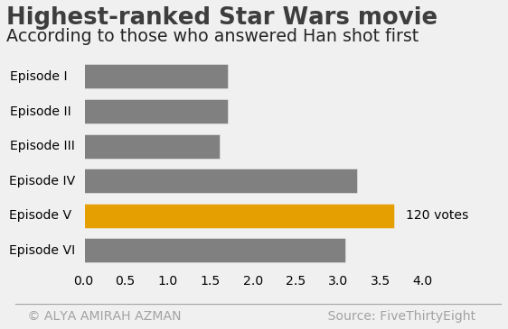

```python
style.use('fivethirtyeight')

# make a bar chart of the mean ranking of each movie among those who answered that Han shot first
(6 - han[han.columns[9:15]].mean()).plot.barh(color=([230/255,159/255,0] if x == min(han[han.columns[9:15]].mean()) else 'grey' for x in han[han.columns[9:15]].mean()), width= 0.7)
plt.yticks([0, 1, 2, 3, 4, 5], ['Episode I   ', 'Episode II  ', 'Episode III ', 'Episode IV ', 'Episode V  ', 'Episode VI '])
plt.gca().invert_yaxis()
plt.grid(b=None)
plt.text(x = -0.8, y = 6.5,
    s = '_____________________________________________________________________________',
    color = 'grey', alpha = .7)

plt.text(x = -0.8, y = 7,
    s = '   © ALYA AMIRAH AZMAN                                    Source: FiveThirtyEight',
    fontsize = 14, color = 'grey', alpha = .7)
plt.text(x = -0.9, y = -1.5, s = "Highest-ranked Star Wars movie",
               fontsize = 26, weight = 'bold', alpha = .75)
plt.text(x = -0.9, y = -1.0,
               s = 'According to those who answered Han shot first',
              fontsize = 19, alpha = .85)
plt.text(x=3.8, y=4.1, s="120 votes")
```

```python
# count the number of votes for Episode V: Empire Strikes Back among those who answered Han shot first
han["ranking_5"].value_counts()
```

```
1.0    120
2.0     94
3.0     47
5.0     31
4.0     22
6.0     11
Name: ranking_5, dtype: int64
```

```python
# check mean ranking of the movies
han[han.columns[9:15]].mean()
```

```
ranking_1    4.295385
ranking_2    4.298462
ranking_3    4.385802
ranking_4    2.769231
ranking_5    2.332308
ranking_6    2.913846
dtype: float64
```

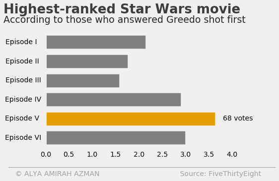

```python
style.use('fivethirtyeight')

# make a bar chart of the mean ranking of each movie among those who answered Greedo shot first
(6 - greedo[greedo.columns[9:15]].mean()).plot.barh(color=([230/255,159/255,0] if x == min(greedo[greedo.columns[9:15]].mean()) else 'grey' for x in greedo[greedo.columns[9:15]].mean()), width= 0.7)
plt.yticks([0, 1, 2, 3, 4, 5], ['Episode I   ', 'Episode II  ', 'Episode III ', 'Episode IV ', 'Episode V  ', 'Episode VI '])
plt.gca().invert_yaxis()
plt.grid(b=None)
plt.text(x = -0.8, y = 6.5,
    s = '_____________________________________________________________________________',
    color = 'grey', alpha = .7)

plt.text(x = -0.8, y = 7,
    s = '   © ALYA AMIRAH AZMAN                                    Source: FiveThirtyEight',
    fontsize = 14, color = 'grey', alpha = .7)
plt.text(x = -0.9, y = -1.5, s = "Highest-ranked Star Wars movie",
               fontsize = 26, weight = 'bold', alpha = .75)
plt.text(x = -0.9, y = -1.0,
               s = 'According to those who answered Greedo shot first',
              fontsize = 19, alpha = .85)
plt.text(x=3.8, y=4.1, s="68 votes")
```

```python
# count the number of votes for Episode V: Empire Strikes Back among those who answered Greedo shot first
greedo["ranking_5"].value_counts()
```

```
1.0    68
2.0    62
3.0    27
5.0    24
4.0    11
6.0     5
Name: ranking_5, dtype: int64
```

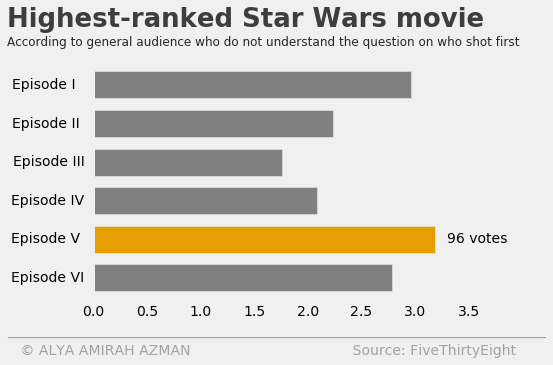

```python
style.use('fivethirtyeight')

# make a bar chart of the mean ranking of each movie among those who do not understand the question on who shot first
(6 - neutral[neutral.columns[9:15]].mean()).plot.barh(color=([230/255,159/255,0] if x == min(neutral[neutral.columns[9:15]].mean()) else 'grey' for x in neutral[neutral.columns[9:15]].mean()), width= 0.7)
plt.yticks([0, 1, 2, 3, 4, 5], ['Episode I   ', 'Episode II  ', 'Episode III ', 'Episode IV ', 'Episode V  ', 'Episode VI '])
plt.gca().invert_yaxis()
plt.grid(b=None)
plt.text(x = -0.8, y = 6.5,
    s = '_____________________________________________________________________________',
    color = 'grey', alpha = .7)

plt.text(x = -0.8, y = 7,
    s = '   © ALYA AMIRAH AZMAN                                    Source: FiveThirtyEight',
    fontsize = 14, color = 'grey', alpha = .7)
plt.text(x = -0.8, y = -1.5, s = "Highest-ranked Star Wars movie",
               fontsize = 26, weight = 'bold', alpha = .75)
plt.text(x = -0.8, y = -1.0,
               s = 'According to general audience who do not understand the question on who shot first',
              fontsize = 12, alpha = .85)
plt.text(x=3.3, y=4.1, s="96 votes")
```

```python
# count the number of votes for Episode V: Empire Strikes Back among those who don't understand the question on who shot first
neutral["ranking_5"].value_counts()
```

```
1.0    96
2.0    77
5.0    62
3.0    32
6.0    25
4.0    14
Name: ranking_5, dtype: int64
```

We segmented the data based on the the question on Which character shot first? and we found that all three groups agreed that Episode V: Empire Strikes Back is the best movie in the Star Wars franchise and they also agreed that the worst movie in the Star Wars franchise is Episode III: Revenge of the Sith.

Those who understood the question disagree on which is the second best movie. Those who answered Han shot first voted Episode IV as the second best movie and those who answered Greedo voted Episode VI as the second best movie. Aside of the 2nd best movie and the 3rd best movie, both groups agreed on the order of the other movies.

Those who do not understand the question voted the other movies differently compared to the two groups. The order are as the following:

| Rank | Han shot first | Greedo shot first | I don't understand the question |
| --- | --- | --- | --- |
| Best | Ep. V | Ep. V | Ep. V |
| 2nd Best | Ep. IV | Ep. VI | Ep. I |
| 3rd Best | Ep. VI | Ep. IV | Ep. VI |
| 4th Best | Ep. I | Ep. I | Ep. II |
| 5th Best | Ep. II | Ep. II | Ep. IV |
| Worst | Ep. III | Ep. III | Ep. III |

We included the previous table we made here for quick comparison.

| Rank | Fans | Non-fans |
| --- | --- | --- |
| Best | Ep. V | Ep. V |
| 2nd Best | Ep. VI | Ep. I |
| 3rd Best | Ep. IV | Ep. VI |
| 4th Best | Ep. I | Ep. II |
| 5th Best | Ep. II | Ep. IV |
| Worst | Ep. III | Ep. III |

It is interesting that the order of the movies from those who answered Han shot first is different than the order of the movies according to results from those who claimed to be Star Wars fans. It is probably due to the fact that fans who answered Han shot first are outnumbered by fans who are new to the fandom and thus, not being able to understand the question and fans who answered Greedo shot first.

**Clean up columns 15 to 29, which contain data on the characters respondents view favorably and unfavorably.**

```python
# see columns 15 to 29
star_wars[star_wars.columns[15:29]]
```

|  | Please state whether you view the following characters favorably, unfavorably, or are unfamiliar with him/her. | Unnamed: 16 | Unnamed: 17 | Unnamed: 18 | Unnamed: 19 | Unnamed: 20 | Unnamed: 21 | Unnamed: 22 | Unnamed: 23 | Unnamed: 24 | Unnamed: 25 | Unnamed: 26 | Unnamed: 27 | Unnamed: 28 |
| --- | --- | --- | --- | --- | --- | --- | --- | --- | --- | --- | --- | --- | --- | --- |
| 1 | Very favorably | Very favorably | Very favorably | Very favorably | Very favorably | Very favorably | Very favorably | Unfamiliar (N/A) | Unfamiliar (N/A) | Very favorably | Very favorably | Very favorably | Very favorably | Very favorably |
| 2 | NaN | NaN | NaN | NaN | NaN | NaN | NaN | NaN | NaN | NaN | NaN | NaN | NaN | NaN |
| 3 | Somewhat favorably | Somewhat favorably | Somewhat favorably | Somewhat favorably | Somewhat favorably | Unfamiliar (N/A) | Unfamiliar (N/A) | Unfamiliar (N/A) | Unfamiliar (N/A) | Unfamiliar (N/A) | Unfamiliar (N/A) | Unfamiliar (N/A) | Unfamiliar (N/A) | Unfamiliar (N/A) |
| 4 | Very favorably | Very favorably | Very favorably | Very favorably | Very favorably | Somewhat favorably | Very favorably | Somewhat favorably | Somewhat unfavorably | Very favorably | Very favorably | Very favorably | Very favorably | Very favorably |
| 5 | Very favorably | Somewhat favorably | Somewhat favorably | Somewhat unfavorably | Very favorably | Very unfavorably | Somewhat favorably | Neither favorably nor unfavorably (neutral) | Very favorably | Somewhat favorably | Somewhat favorably | Very unfavorably | Somewhat favorably | Somewhat favorably |
| 6 | Very favorably | Very favorably | Very favorably | Very favorably | Very favorably | Neither favorably nor unfavorably (neutral) | Very favorably | Neither favorably nor unfavorably (neutral) | Somewhat favorably | Somewhat favorably | Somewhat favorably | Somewhat favorably | Neither favorably nor unfavorably (neutral) | Very favorably |
| 7 | Very favorably | Very favorably | Somewhat favorably | Somewhat favorably | Very favorably | Very favorably | Very favorably | Very favorably | Very favorably | Somewhat favorably | Very favorably | Somewhat unfavorably | Somewhat favorably | Very favorably |
| 8 | Very favorably | Somewhat favorably | Very favorably | Neither favorably nor unfavorably (neutral) | Very favorably | Very unfavorably | Somewhat unfavorably | Neither favorably nor unfavorably (neutral) | Somewhat favorably | Somewhat favorably | Somewhat favorably | Very unfavorably | Somewhat unfavorably | Very favorably |
| 9 | Very favorably | Somewhat unfavorably | Somewhat favorably | Somewhat favorably | Somewhat favorably | Very favorably | Very favorably | Very favorably | Very favorably | Neither favorably nor unfavorably (neutral) | Somewhat favorably | Very unfavorably | Somewhat unfavorably | Somewhat favorably |
| 10 | Neither favorably nor unfavorably (neutral) | Very favorably | Very favorably | Very favorably | Very favorably | Somewhat unfavorably | Very favorably | Somewhat unfavorably | Somewhat unfavorably | Very favorably | Very favorably | Very favorably | Somewhat unfavorably | Very favorably |
| 11 | NaN | NaN | NaN | NaN | NaN | NaN | NaN | NaN | NaN | NaN | NaN | NaN | NaN | NaN |
| 12 | NaN | NaN | NaN | NaN | NaN | NaN | NaN | NaN | NaN | NaN | NaN | NaN | NaN | NaN |
| 13 | Somewhat favorably | Very favorably | Somewhat favorably | Somewhat favorably | Somewhat favorably | Somewhat favorably | Very favorably | Neither favorably nor unfavorably (neutral) | Somewhat favorably | Very favorably | Very favorably | Very favorably | Somewhat favorably | Very favorably |
| 14 | Very favorably | Very favorably | Very favorably | Somewhat favorably | Very favorably | Unfamiliar (N/A) | Very unfavorably | Unfamiliar (N/A) | Neither favorably nor unfavorably (neutral) | Very favorably | Very favorably | Unfamiliar (N/A) | Very favorably | Very favorably |
| 15 | Somewhat favorably | Very favorably | Very favorably | Somewhat favorably | Very favorably | Very unfavorably | Very unfavorably | Very unfavorably | Very unfavorably | Very favorably | Very favorably | Very favorably | Very favorably | Very favorably |
| 16 | Very favorably | Somewhat favorably | Somewhat favorably | Somewhat unfavorably | Very favorably | Somewhat favorably | Very favorably | Somewhat favorably | Very favorably | Somewhat unfavorably | Neither favorably nor unfavorably (neutral) | Very unfavorably | Very unfavorably | Somewhat favorably |
| 17 | Neither favorably nor unfavorably (neutral) | Somewhat favorably | Somewhat unfavorably | Neither favorably nor unfavorably (neutral) | Very unfavorably | Somewhat favorably | Somewhat unfavorably | Neither favorably nor unfavorably (neutral) | Somewhat favorably | Neither favorably nor unfavorably (neutral) | Somewhat unfavorably | Neither favorably nor unfavorably (neutral) | Somewhat unfavorably | Very unfavorably |
| 18 | Very favorably | Very favorably | Very favorably | Very favorably | Very favorably | Somewhat favorably | Very favorably | Neither favorably nor unfavorably (neutral) | Somewhat favorably | Very favorably | Very favorably | Very favorably | Very favorably | Very favorably |
| 19 | Very favorably | Very favorably | Very favorably | Very favorably | Very favorably | Very favorably | Very favorably | Somewhat favorably | Very favorably | Very favorably | Very favorably | Very unfavorably | Somewhat unfavorably | Very favorably |
| 20 | Very favorably | Somewhat favorably | Very favorably | Very favorably | Somewhat favorably | Somewhat unfavorably | Very favorably | Very unfavorably | Very favorably | Somewhat favorably | Very favorably | Somewhat unfavorably | Very favorably | Very favorably |
| 21 | Very favorably | Very favorably | Somewhat favorably | Somewhat favorably | Very favorably | Neither favorably nor unfavorably (neutral) | Somewhat favorably | Neither favorably nor unfavorably (neutral) | Very favorably | Somewhat favorably | Somewhat favorably | Very unfavorably | Neither favorably nor unfavorably (neutral) | Very favorably |
| 22 | Neither favorably nor unfavorably (neutral) | Neither favorably nor unfavorably (neutral) | Neither favorably nor unfavorably (neutral) | Neither favorably nor unfavorably (neutral) | Neither favorably nor unfavorably (neutral) | Neither favorably nor unfavorably (neutral) | Neither favorably nor unfavorably (neutral) | Neither favorably nor unfavorably (neutral) | Neither favorably nor unfavorably (neutral) | Neither favorably nor unfavorably (neutral) | Neither favorably nor unfavorably (neutral) | Neither favorably nor unfavorably (neutral) | Neither favorably nor unfavorably (neutral) | Neither favorably nor unfavorably (neutral) |
| 23 | Very favorably | Very favorably | Very favorably | Neither favorably nor unfavorably (neutral) | Very favorably | Very unfavorably | Somewhat favorably | Somewhat favorably | Somewhat unfavorably | Very favorably | Very favorably | Very unfavorably | Neither favorably nor unfavorably (neutral) | Very favorably |
| 24 | Very favorably | Somewhat favorably | Somewhat favorably | Somewhat unfavorably | Somewhat favorably | Somewhat favorably | Very favorably | Neither favorably nor unfavorably (neutral) | Neither favorably nor unfavorably (neutral) | Somewhat favorably | Very favorably | Somewhat favorably | Neither favorably nor unfavorably (neutral) | Very favorably |
| 25 | Very favorably | Very favorably | Very favorably | Very favorably | Very favorably | Very favorably | Very favorably | Very favorably | Very favorably | Very favorably | Very favorably | Very favorably | Very favorably | Very favorably |
| 26 | NaN | NaN | NaN | NaN | NaN | NaN | NaN | NaN | NaN | NaN | NaN | NaN | NaN | NaN |
| 27 | Very favorably | Somewhat favorably | Somewhat favorably | Somewhat favorably | Very favorably | Somewhat favorably | Somewhat favorably | Somewhat favorably | Very favorably | Very favorably | Very favorably | Very unfavorably | Somewhat favorably | Very favorably |
| 28 | Very favorably | Very favorably | Very favorably | Somewhat favorably | Very favorably | Very unfavorably | Very unfavorably | Somewhat favorably | Somewhat unfavorably | Very favorably | Very favorably | Very favorably | Very favorably | Very favorably |
| 29 | Very favorably | Somewhat favorably | Neither favorably nor unfavorably (neutral) | Very unfavorably | Very unfavorably | Very unfavorably | Very favorably | Very favorably | Somewhat favorably | Very unfavorably | Somewhat unfavorably | Very unfavorably | Very unfavorably | Very favorably |
| 30 | Very favorably | Very favorably | Very favorably | Very unfavorably | Very favorably | Very favorably | Very favorably | Very favorably | Very favorably | Very favorably | Very favorably | Unfamiliar (N/A) | Very unfavorably | Very favorably |
| ... | ... | ... | ... | ... | ... | ... | ... | ... | ... | ... | ... | ... | ... | ... |
| 1157 | Very favorably | Very favorably | Very favorably | Very favorably | Very favorably | Very favorably | Very unfavorably | Neither favorably nor unfavorably (neutral) | Somewhat favorably | Very favorably | Very favorably | Very favorably | Very favorably | Very favorably |
| 1158 | NaN | NaN | NaN | NaN | NaN | NaN | NaN | NaN | NaN | NaN | NaN | NaN | NaN | NaN |
| 1159 | Very favorably | Very favorably | Very favorably | Neither favorably nor unfavorably (neutral) | Very favorably | Neither favorably nor unfavorably (neutral) | Somewhat favorably | Neither favorably nor unfavorably (neutral) | Neither favorably nor unfavorably (neutral) | Very favorably | Very favorably | Neither favorably nor unfavorably (neutral) | Neither favorably nor unfavorably (neutral) | Very favorably |
| 1160 | NaN | NaN | NaN | NaN | NaN | NaN | NaN | NaN | NaN | NaN | NaN | NaN | NaN | NaN |
| 1161 | Somewhat favorably | Very favorably | Somewhat favorably | Somewhat favorably | Very favorably | Somewhat favorably | Somewhat favorably | Somewhat favorably | Somewhat favorably | Somewhat favorably | Very favorably | Very favorably | Somewhat favorably | Very favorably |
| 1162 | Somewhat favorably | Somewhat favorably | Somewhat favorably | Somewhat favorably | Somewhat favorably | Somewhat favorably | Somewhat unfavorably | Neither favorably nor unfavorably (neutral) | Neither favorably nor unfavorably (neutral) | Somewhat favorably | Somewhat favorably | Somewhat unfavorably | Neither favorably nor unfavorably (neutral) | Neither favorably nor unfavorably (neutral) |
| 1163 | Somewhat favorably | Somewhat favorably | Somewhat favorably | Very unfavorably | NaN | Very favorably | Very unfavorably | Neither favorably nor unfavorably (neutral) | Somewhat unfavorably | Very favorably | Very favorably | Neither favorably nor unfavorably (neutral) | Somewhat favorably | Very favorably |
| 1164 | Very favorably | Very favorably | Very favorably | Neither favorably nor unfavorably (neutral) | Very favorably | NaN | Somewhat unfavorably | Very favorably | Somewhat unfavorably | Very favorably | Very favorably | Very favorably | Very favorably | Very favorably |
| 1165 | Somewhat favorably | Somewhat favorably | Somewhat favorably | Somewhat favorably | Somewhat favorably | Somewhat favorably | Somewhat unfavorably | Somewhat favorably | Neither favorably nor unfavorably (neutral) | Somewhat favorably | Somewhat favorably | Somewhat unfavorably | Somewhat unfavorably | Neither favorably nor unfavorably (neutral) |
| 1166 | Very favorably | Very favorably | Very favorably | Very favorably | Very favorably | Unfamiliar (N/A) | Very favorably | Very favorably | Very favorably | Very favorably | Very favorably | Unfamiliar (N/A) | Very favorably | Very favorably |
| 1167 | Very favorably | Very favorably | Very favorably | Very favorably | Very favorably | Somewhat unfavorably | Somewhat favorably | Unfamiliar (N/A) | Somewhat favorably | Somewhat favorably | Somewhat favorably | Somewhat unfavorably | Very favorably | Very favorably |
| 1168 | Very favorably | Very favorably | Very favorably | Very favorably | Very favorably | Unfamiliar (N/A) | Very favorably | Unfamiliar (N/A) | Unfamiliar (N/A) | Very favorably | Very favorably | Unfamiliar (N/A) | Neither favorably nor unfavorably (neutral) | Very favorably |
| 1169 | NaN | NaN | NaN | NaN | NaN | NaN | NaN | NaN | NaN | NaN | NaN | NaN | NaN | NaN |
| 1170 | Very favorably | Very favorably | Very favorably | Neither favorably nor unfavorably (neutral) | Very favorably | Somewhat favorably | Very favorably | Very favorably | Somewhat favorably | Very favorably | Very favorably | Very unfavorably | Somewhat unfavorably | Very favorably |
| 1171 | NaN | NaN | NaN | NaN | NaN | NaN | NaN | NaN | NaN | NaN | NaN | NaN | NaN | NaN |
| 1172 | Very favorably | Very favorably | Very favorably | Somewhat favorably | Very favorably | Very favorably | Very favorably | Somewhat unfavorably | Very unfavorably | Very favorably | Very favorably | Neither favorably nor unfavorably (neutral) | Neither favorably nor unfavorably (neutral) | Somewhat unfavorably |
| 1173 | Very favorably | Very favorably | Very favorably | Very favorably | Very favorably | Neither favorably nor unfavorably (neutral) | Very unfavorably | Neither favorably nor unfavorably (neutral) | Neither favorably nor unfavorably (neutral) | Very favorably | Very favorably | Neither favorably nor unfavorably (neutral) | Neither favorably nor unfavorably (neutral) | Somewhat favorably |
| 1174 | Very favorably | Very favorably | Very favorably | Very favorably | Very favorably | Somewhat favorably | Very favorably | Unfamiliar (N/A) | Very favorably | Very favorably | Very favorably | Somewhat favorably | Very favorably | Very favorably |
| 1175 | Very favorably | Very favorably | Very favorably | Very favorably | Very favorably | Unfamiliar (N/A) | Very favorably | Unfamiliar (N/A) | Unfamiliar (N/A) | Very favorably | Very favorably | Unfamiliar (N/A) | Unfamiliar (N/A) | Very favorably |
| 1176 | Very favorably | Neither favorably nor unfavorably (neutral) | Somewhat favorably | Very favorably | Somewhat favorably | Neither favorably nor unfavorably (neutral) | Very favorably | Neither favorably nor unfavorably (neutral) | Somewhat favorably | Somewhat favorably | Very favorably | Neither favorably nor unfavorably (neutral) | Neither favorably nor unfavorably (neutral) | Somewhat favorably |
| 1177 | Neither favorably nor unfavorably (neutral) | Neither favorably nor unfavorably (neutral) | Neither favorably nor unfavorably (neutral) | Neither favorably nor unfavorably (neutral) | Neither favorably nor unfavorably (neutral) | Neither favorably nor unfavorably (neutral) | Neither favorably nor unfavorably (neutral) | Neither favorably nor unfavorably (neutral) | Neither favorably nor unfavorably (neutral) | Neither favorably nor unfavorably (neutral) | Neither favorably nor unfavorably (neutral) | Neither favorably nor unfavorably (neutral) | Neither favorably nor unfavorably (neutral) | Neither favorably nor unfavorably (neutral) |
| 1178 | Very favorably | Somewhat favorably | Very favorably | Very favorably | Somewhat favorably | Neither favorably nor unfavorably (neutral) | Neither favorably nor unfavorably (neutral) | Unfamiliar (N/A) | Unfamiliar (N/A) | Very favorably | Very favorably | Very favorably | Unfamiliar (N/A) | Very favorably |
| 1179 | NaN | NaN | NaN | NaN | NaN | NaN | NaN | NaN | NaN | NaN | NaN | NaN | NaN | NaN |
| 1180 | Very favorably | Very favorably | Very favorably | Neither favorably nor unfavorably (neutral) | Very favorably | Neither favorably nor unfavorably (neutral) | Very unfavorably | Neither favorably nor unfavorably (neutral) | Neither favorably nor unfavorably (neutral) | Very favorably | Very favorably | Neither favorably nor unfavorably (neutral) | Neither favorably nor unfavorably (neutral) | Very favorably |
| 1181 | Very favorably | Very favorably | Very favorably | Somewhat favorably | Very favorably | Somewhat favorably | Very favorably | Somewhat favorably | Somewhat favorably | Very favorably | Very favorably | Somewhat favorably | Somewhat favorably | Very favorably |
| 1182 | Very favorably | Somewhat favorably | Somewhat favorably | Somewhat favorably | Very favorably | Somewhat favorably | Somewhat favorably | Somewhat favorably | Somewhat favorably | Very favorably | Very favorably | Somewhat favorably | Somewhat favorably | Very favorably |
| 1183 | Very favorably | Somewhat favorably | Very favorably | Somewhat unfavorably | Very favorably | Neither favorably nor unfavorably (neutral) | Very unfavorably | Somewhat favorably | Unfamiliar (N/A) | Somewhat favorably | Very favorably | Somewhat unfavorably | Somewhat unfavorably | Very favorably |
| 1184 | NaN | NaN | NaN | NaN | NaN | NaN | NaN | NaN | NaN | NaN | NaN | NaN | NaN | NaN |
| 1185 | Very favorably | Neither favorably nor unfavorably (neutral) | Very favorably | Very favorably | Very favorably | Neither favorably nor unfavorably (neutral) | Very favorably | Somewhat favorably | Very favorably | Somewhat favorably | Somewhat favorably | Very favorably | Somewhat favorably | Very favorably |
| 1186 | Very favorably | Very favorably | Very favorably | Very unfavorably | Very favorably | Very unfavorably | Very favorably | Very unfavorably | Unfamiliar (N/A) | Somewhat favorably | Somewhat favorably | Very unfavorably | Neither favorably nor unfavorably (neutral) | Very unfavorably |

1186 rows × 14 columns

```python
# see character names stored earlier
characters
```

|  | Please state whether you view the following characters favorably, unfavorably, or are unfamiliar with him/her. | Unnamed: 16 | Unnamed: 17 | Unnamed: 18 | Unnamed: 19 | Unnamed: 20 | Unnamed: 21 | Unnamed: 22 | Unnamed: 23 | Unnamed: 24 | Unnamed: 25 | Unnamed: 26 | Unnamed: 27 | Unnamed: 28 |
| --- | --- | --- | --- | --- | --- | --- | --- | --- | --- | --- | --- | --- | --- | --- |
| 0 | Han Solo | Luke Skywalker | Princess Leia Organa | Anakin Skywalker | Obi Wan Kenobi | Emperor Palpatine | Darth Vader | Lando Calrissian | Boba Fett | C-3P0 | R2 D2 | Jar Jar Binks | Padme Amidala | Yoda |

```python
# check possible values in columns
star_wars["Unnamed: 16"].value_counts()
```

```
Very favorably                                 552
Somewhat favorably                             219
Neither favorably nor unfavorably (neutral)     38
Somewhat unfavorably                            13
Unfamiliar (N/A)                                 6
Very unfavorably                                 3
Name: Unnamed: 16, dtype: int64
```

```python
# check missing values
star_wars["Unnamed: 16"].isna().sum()
```

```
355
```

```python
# check missing values
star_wars["Unnamed: 28"].isna().sum()
```

```
360
```

```python
# make a dictionary to convert values
char_val = {"Very favorably": 2,
            "Somewhat favorably": 1,
            "Neither favorably nor unfavorably (neutral)": 0,
            "Somewhat unfavorably": -1,
            "Unfamiliar (N/A)": 0,
            "Very unfavorably": -2,
            np.nan: 0}

# convert values in column 15 to 29 to numbers
for c in star_wars.columns[15:29]:
    star_wars[c] = star_wars[c].map(char_val)

# convert data type in columns to float
star_wars[star_wars.columns[15:29]] = star_wars[star_wars.columns[15:29]].astype(float)

# make a dictionary of column names to change
char_name = {"Please state whether you view the following characters favorably, unfavorably, or are unfamiliar with him/her.": "Han Solo",
             "Unnamed: 16": "Luke Skywalker",
             "Unnamed: 17": "Princess Leia Organa",
             "Unnamed: 18": "Anakin Skywalker",
             "Unnamed: 19": "Obi Wan Kenobi",
             "Unnamed: 20": "Emperor Palpatine",
             "Unnamed: 21": "Darth Vader",
             "Unnamed: 22": "Lando Calrissian",
             "Unnamed: 23": "Boba Fett",
             "Unnamed: 24": "C-3PO",
             "Unnamed: 25": "R2 D2",
             "Unnamed: 26": "Jar Jar Binks",
             "Unnamed: 27": "Padme Amidala",
             "Unnamed: 28": "Yoda"}

# rename column names
star_wars = star_wars.rename(char_name, axis =1)

# check data set to double check
star_wars[star_wars.columns[15:29]]
```

|  | Han Solo | Luke Skywalker | Princess Leia Organa | Anakin Skywalker | Obi Wan Kenobi | Emperor Palpatine | Darth Vader | Lando Calrissian | Boba Fett | C-3PO | R2 D2 | Jar Jar Binks | Padme Amidala | Yoda |
| --- | --- | --- | --- | --- | --- | --- | --- | --- | --- | --- | --- | --- | --- | --- |
| 1 | 2.0 | 2.0 | 2.0 | 2.0 | 2.0 | 2.0 | 2.0 | 0.0 | 0.0 | 2.0 | 2.0 | 2.0 | 2.0 | 2.0 |
| 2 | 0.0 | 0.0 | 0.0 | 0.0 | 0.0 | 0.0 | 0.0 | 0.0 | 0.0 | 0.0 | 0.0 | 0.0 | 0.0 | 0.0 |
| 3 | 1.0 | 1.0 | 1.0 | 1.0 | 1.0 | 0.0 | 0.0 | 0.0 | 0.0 | 0.0 | 0.0 | 0.0 | 0.0 | 0.0 |
| 4 | 2.0 | 2.0 | 2.0 | 2.0 | 2.0 | 1.0 | 2.0 | 1.0 | -1.0 | 2.0 | 2.0 | 2.0 | 2.0 | 2.0 |
| 5 | 2.0 | 1.0 | 1.0 | -1.0 | 2.0 | -2.0 | 1.0 | 0.0 | 2.0 | 1.0 | 1.0 | -2.0 | 1.0 | 1.0 |
| 6 | 2.0 | 2.0 | 2.0 | 2.0 | 2.0 | 0.0 | 2.0 | 0.0 | 1.0 | 1.0 | 1.0 | 1.0 | 0.0 | 2.0 |
| 7 | 2.0 | 2.0 | 1.0 | 1.0 | 2.0 | 2.0 | 2.0 | 2.0 | 2.0 | 1.0 | 2.0 | -1.0 | 1.0 | 2.0 |
| 8 | 2.0 | 1.0 | 2.0 | 0.0 | 2.0 | -2.0 | -1.0 | 0.0 | 1.0 | 1.0 | 1.0 | -2.0 | -1.0 | 2.0 |
| 9 | 2.0 | -1.0 | 1.0 | 1.0 | 1.0 | 2.0 | 2.0 | 2.0 | 2.0 | 0.0 | 1.0 | -2.0 | -1.0 | 1.0 |
| 10 | 0.0 | 2.0 | 2.0 | 2.0 | 2.0 | -1.0 | 2.0 | -1.0 | -1.0 | 2.0 | 2.0 | 2.0 | -1.0 | 2.0 |
| 11 | 0.0 | 0.0 | 0.0 | 0.0 | 0.0 | 0.0 | 0.0 | 0.0 | 0.0 | 0.0 | 0.0 | 0.0 | 0.0 | 0.0 |
| 12 | 0.0 | 0.0 | 0.0 | 0.0 | 0.0 | 0.0 | 0.0 | 0.0 | 0.0 | 0.0 | 0.0 | 0.0 | 0.0 | 0.0 |
| 13 | 1.0 | 2.0 | 1.0 | 1.0 | 1.0 | 1.0 | 2.0 | 0.0 | 1.0 | 2.0 | 2.0 | 2.0 | 1.0 | 2.0 |
| 14 | 2.0 | 2.0 | 2.0 | 1.0 | 2.0 | 0.0 | -2.0 | 0.0 | 0.0 | 2.0 | 2.0 | 0.0 | 2.0 | 2.0 |
| 15 | 1.0 | 2.0 | 2.0 | 1.0 | 2.0 | -2.0 | -2.0 | -2.0 | -2.0 | 2.0 | 2.0 | 2.0 | 2.0 | 2.0 |
| 16 | 2.0 | 1.0 | 1.0 | -1.0 | 2.0 | 1.0 | 2.0 | 1.0 | 2.0 | -1.0 | 0.0 | -2.0 | -2.0 | 1.0 |
| 17 | 0.0 | 1.0 | -1.0 | 0.0 | -2.0 | 1.0 | -1.0 | 0.0 | 1.0 | 0.0 | -1.0 | 0.0 | -1.0 | -2.0 |
| 18 | 2.0 | 2.0 | 2.0 | 2.0 | 2.0 | 1.0 | 2.0 | 0.0 | 1.0 | 2.0 | 2.0 | 2.0 | 2.0 | 2.0 |
| 19 | 2.0 | 2.0 | 2.0 | 2.0 | 2.0 | 2.0 | 2.0 | 1.0 | 2.0 | 2.0 | 2.0 | -2.0 | -1.0 | 2.0 |
| 20 | 2.0 | 1.0 | 2.0 | 2.0 | 1.0 | -1.0 | 2.0 | -2.0 | 2.0 | 1.0 | 2.0 | -1.0 | 2.0 | 2.0 |
| 21 | 2.0 | 2.0 | 1.0 | 1.0 | 2.0 | 0.0 | 1.0 | 0.0 | 2.0 | 1.0 | 1.0 | -2.0 | 0.0 | 2.0 |
| 22 | 0.0 | 0.0 | 0.0 | 0.0 | 0.0 | 0.0 | 0.0 | 0.0 | 0.0 | 0.0 | 0.0 | 0.0 | 0.0 | 0.0 |
| 23 | 2.0 | 2.0 | 2.0 | 0.0 | 2.0 | -2.0 | 1.0 | 1.0 | -1.0 | 2.0 | 2.0 | -2.0 | 0.0 | 2.0 |
| 24 | 2.0 | 1.0 | 1.0 | -1.0 | 1.0 | 1.0 | 2.0 | 0.0 | 0.0 | 1.0 | 2.0 | 1.0 | 0.0 | 2.0 |
| 25 | 2.0 | 2.0 | 2.0 | 2.0 | 2.0 | 2.0 | 2.0 | 2.0 | 2.0 | 2.0 | 2.0 | 2.0 | 2.0 | 2.0 |
| 26 | 0.0 | 0.0 | 0.0 | 0.0 | 0.0 | 0.0 | 0.0 | 0.0 | 0.0 | 0.0 | 0.0 | 0.0 | 0.0 | 0.0 |
| 27 | 2.0 | 1.0 | 1.0 | 1.0 | 2.0 | 1.0 | 1.0 | 1.0 | 2.0 | 2.0 | 2.0 | -2.0 | 1.0 | 2.0 |
| 28 | 2.0 | 2.0 | 2.0 | 1.0 | 2.0 | -2.0 | -2.0 | 1.0 | -1.0 | 2.0 | 2.0 | 2.0 | 2.0 | 2.0 |
| 29 | 2.0 | 1.0 | 0.0 | -2.0 | -2.0 | -2.0 | 2.0 | 2.0 | 1.0 | -2.0 | -1.0 | -2.0 | -2.0 | 2.0 |
| 30 | 2.0 | 2.0 | 2.0 | -2.0 | 2.0 | 2.0 | 2.0 | 2.0 | 2.0 | 2.0 | 2.0 | 0.0 | -2.0 | 2.0 |
| ... | ... | ... | ... | ... | ... | ... | ... | ... | ... | ... | ... | ... | ... | ... |
| 1157 | 2.0 | 2.0 | 2.0 | 2.0 | 2.0 | 2.0 | -2.0 | 0.0 | 1.0 | 2.0 | 2.0 | 2.0 | 2.0 | 2.0 |
| 1158 | 0.0 | 0.0 | 0.0 | 0.0 | 0.0 | 0.0 | 0.0 | 0.0 | 0.0 | 0.0 | 0.0 | 0.0 | 0.0 | 0.0 |
| 1159 | 2.0 | 2.0 | 2.0 | 0.0 | 2.0 | 0.0 | 1.0 | 0.0 | 0.0 | 2.0 | 2.0 | 0.0 | 0.0 | 2.0 |
| 1160 | 0.0 | 0.0 | 0.0 | 0.0 | 0.0 | 0.0 | 0.0 | 0.0 | 0.0 | 0.0 | 0.0 | 0.0 | 0.0 | 0.0 |
| 1161 | 1.0 | 2.0 | 1.0 | 1.0 | 2.0 | 1.0 | 1.0 | 1.0 | 1.0 | 1.0 | 2.0 | 2.0 | 1.0 | 2.0 |
| 1162 | 1.0 | 1.0 | 1.0 | 1.0 | 1.0 | 1.0 | -1.0 | 0.0 | 0.0 | 1.0 | 1.0 | -1.0 | 0.0 | 0.0 |
| 1163 | 1.0 | 1.0 | 1.0 | -2.0 | 0.0 | 2.0 | -2.0 | 0.0 | -1.0 | 2.0 | 2.0 | 0.0 | 1.0 | 2.0 |
| 1164 | 2.0 | 2.0 | 2.0 | 0.0 | 2.0 | 0.0 | -1.0 | 2.0 | -1.0 | 2.0 | 2.0 | 2.0 | 2.0 | 2.0 |
| 1165 | 1.0 | 1.0 | 1.0 | 1.0 | 1.0 | 1.0 | -1.0 | 1.0 | 0.0 | 1.0 | 1.0 | -1.0 | -1.0 | 0.0 |
| 1166 | 2.0 | 2.0 | 2.0 | 2.0 | 2.0 | 0.0 | 2.0 | 2.0 | 2.0 | 2.0 | 2.0 | 0.0 | 2.0 | 2.0 |
| 1167 | 2.0 | 2.0 | 2.0 | 2.0 | 2.0 | -1.0 | 1.0 | 0.0 | 1.0 | 1.0 | 1.0 | -1.0 | 2.0 | 2.0 |
| 1168 | 2.0 | 2.0 | 2.0 | 2.0 | 2.0 | 0.0 | 2.0 | 0.0 | 0.0 | 2.0 | 2.0 | 0.0 | 0.0 | 2.0 |
| 1169 | 0.0 | 0.0 | 0.0 | 0.0 | 0.0 | 0.0 | 0.0 | 0.0 | 0.0 | 0.0 | 0.0 | 0.0 | 0.0 | 0.0 |
| 1170 | 2.0 | 2.0 | 2.0 | 0.0 | 2.0 | 1.0 | 2.0 | 2.0 | 1.0 | 2.0 | 2.0 | -2.0 | -1.0 | 2.0 |
| 1171 | 0.0 | 0.0 | 0.0 | 0.0 | 0.0 | 0.0 | 0.0 | 0.0 | 0.0 | 0.0 | 0.0 | 0.0 | 0.0 | 0.0 |
| 1172 | 2.0 | 2.0 | 2.0 | 1.0 | 2.0 | 2.0 | 2.0 | -1.0 | -2.0 | 2.0 | 2.0 | 0.0 | 0.0 | -1.0 |
| 1173 | 2.0 | 2.0 | 2.0 | 2.0 | 2.0 | 0.0 | -2.0 | 0.0 | 0.0 | 2.0 | 2.0 | 0.0 | 0.0 | 1.0 |
| 1174 | 2.0 | 2.0 | 2.0 | 2.0 | 2.0 | 1.0 | 2.0 | 0.0 | 2.0 | 2.0 | 2.0 | 1.0 | 2.0 | 2.0 |
| 1175 | 2.0 | 2.0 | 2.0 | 2.0 | 2.0 | 0.0 | 2.0 | 0.0 | 0.0 | 2.0 | 2.0 | 0.0 | 0.0 | 2.0 |
| 1176 | 2.0 | 0.0 | 1.0 | 2.0 | 1.0 | 0.0 | 2.0 | 0.0 | 1.0 | 1.0 | 2.0 | 0.0 | 0.0 | 1.0 |
| 1177 | 0.0 | 0.0 | 0.0 | 0.0 | 0.0 | 0.0 | 0.0 | 0.0 | 0.0 | 0.0 | 0.0 | 0.0 | 0.0 | 0.0 |
| 1178 | 2.0 | 1.0 | 2.0 | 2.0 | 1.0 | 0.0 | 0.0 | 0.0 | 0.0 | 2.0 | 2.0 | 2.0 | 0.0 | 2.0 |
| 1179 | 0.0 | 0.0 | 0.0 | 0.0 | 0.0 | 0.0 | 0.0 | 0.0 | 0.0 | 0.0 | 0.0 | 0.0 | 0.0 | 0.0 |
| 1180 | 2.0 | 2.0 | 2.0 | 0.0 | 2.0 | 0.0 | -2.0 | 0.0 | 0.0 | 2.0 | 2.0 | 0.0 | 0.0 | 2.0 |
| 1181 | 2.0 | 2.0 | 2.0 | 1.0 | 2.0 | 1.0 | 2.0 | 1.0 | 1.0 | 2.0 | 2.0 | 1.0 | 1.0 | 2.0 |
| 1182 | 2.0 | 1.0 | 1.0 | 1.0 | 2.0 | 1.0 | 1.0 | 1.0 | 1.0 | 2.0 | 2.0 | 1.0 | 1.0 | 2.0 |
| 1183 | 2.0 | 1.0 | 2.0 | -1.0 | 2.0 | 0.0 | -2.0 | 1.0 | 0.0 | 1.0 | 2.0 | -1.0 | -1.0 | 2.0 |
| 1184 | 0.0 | 0.0 | 0.0 | 0.0 | 0.0 | 0.0 | 0.0 | 0.0 | 0.0 | 0.0 | 0.0 | 0.0 | 0.0 | 0.0 |
| 1185 | 2.0 | 0.0 | 2.0 | 2.0 | 2.0 | 0.0 | 2.0 | 1.0 | 2.0 | 1.0 | 1.0 | 2.0 | 1.0 | 2.0 |
| 1186 | 2.0 | 2.0 | 2.0 | -2.0 | 2.0 | -2.0 | 2.0 | -2.0 | 0.0 | 1.0 | 1.0 | -2.0 | 0.0 | -2.0 |

1186 rows × 14 columns

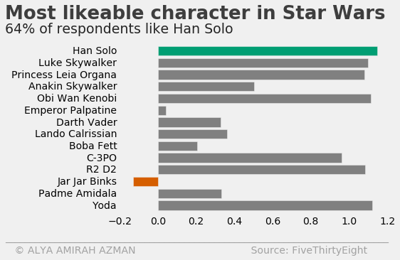

```python
style.use('fivethirtyeight')

colors_v2 = []

for i in range(14):
    if i == 0:
        colors_v2.append([0,158/255,115/255])
    elif i == 11:
        colors_v2.append([213/255,94/255,0])
    else:
        colors_v2.append('grey')

# star_wars[star_wars.columns[15:29]].mean().plot.barh(color=([0,158/255,115/255] if x == max(star_wars[star_wars.columns[15:29]].mean()) else 'grey' for x in star_wars[star_wars.columns[15:29]].mean()), width= 0.7)
star_wars[star_wars.columns[15:29]].mean().plot.barh(color=colors_v2, width=0.8)
plt.grid(b=None)
plt.gca().invert_yaxis()
plt.text(x = -0.8, y = 16,
    s = '_____________________________________________________________________________',
    color = 'grey', alpha = .7)

plt.text(x = -0.8, y = 17,
    s = '   © ALYA AMIRAH AZMAN                                    Source: FiveThirtyEight',
    fontsize = 14, color = 'grey', alpha = .7)
plt.text(x = -0.8, y = -2.7, s = "Most likeable character in Star Wars",
               fontsize = 26, weight = 'bold', alpha = .75)
plt.text(x = -0.8, y = -1.5,
               s = '64% of respondents like Han Solo',
              fontsize = 19, alpha = .85)
#plt.text(x=1.2, y=0.25, s="761 votes")
#plt.text(x=0.05, y=11.25, s="306")
```

```python
# count the number of votes who responded that they like Han Solo
star_wars["Han Solo"].value_counts()
```

```
 2.0    610
 0.0    416
 1.0    151
-1.0      8
-2.0      1
Name: Han Solo, dtype: int64
```

```python
# count the number of votes who responded that they like Luke Skywalker
star_wars["Luke Skywalker"].value_counts()
```

```
 2.0    552
 0.0    399
 1.0    219
-1.0     13
-2.0      3
Name: Luke Skywalker, dtype: int64
```

```python
# count the number of votes who responded that they like Han Solo
star_wars["Jar Jar Binks"].value_counts()
```

```
 0.0    638
-2.0    204
 1.0    130
 2.0    112
-1.0    102
Name: Jar Jar Binks, dtype: int64
```

```python
# convert number of votes to percentages
((star_wars["Han Solo"].value_counts())/1186)*100
```

```
 2.0    51.433390
 0.0    35.075885
 1.0    12.731872
-1.0     0.674536
-2.0     0.084317
Name: Han Solo, dtype: float64
```

```python
star_wars["Anakin Skywalker"].value_counts()
```

```
 0.0    550
 1.0    269
 2.0    245
-1.0     83
-2.0     39
Name: Anakin Skywalker, dtype: int64
```

- Very favorably: 2 points
- Somewhat favorably: 1 point
- Neither favorably nor unfavorably (neutral): 0
- Somewhat unfavorably: -1 point
- Unfamiliar (N/A): 0 point
- Very unfavorably: -2 points

Based on the points, we could check how favorable the characters are by the points given. From our plot, we found Han Solo to be the most likeable character in the Star Wars franchise and we also found Jar Jar Binks to be the least likeable Star Wars character.

# Conclusion

In this project, we analyzed the survey results on Star Wars movies by FiveThirtyEight.

We spend most of our analysis on checking the rankings of the movies by different groups such as fans and non-fans. From the rankings, we found Episode V: Empire Strikes Back to be the best Star Wars movie and Episode III: Revenge of the Sith to be the worst Star Wars movie.

552 out of 1186 respondents claimed to be a Star Wars fan. However, we were quite surprised to find that 14 fans haven't watched Episode IV. We were expecting Star Wars fans to have watched all 6 movies or at least the original trilogy (Episode IV, V & VI), so it is weird for us to find fans who haven't watch those movies.

If we are redoing the analysis, we probably would split the respondents to those who have watched all 6 movies with those who haven't watched all 6 movies.